# Wallpaper sorting study data surgery

Rick Gilmore

2021-04-22 13:18:05

# Purpose

This document describes the process involved in creating datasets for analysis of the symmetry sorting study data. There are two types of data files.

One is at the wallpaper exemplar pair level. For each wallpaper exemplar pair, this data file should have the Jaccard index, a link to the actual image(s) (e.g., on Databrary), and any pair-wise image similarity metrics available for the pair, such as SSID, dot product, etc. The file also includes the wallpaper group associated with each exemplar pair.

The second data file is at the individual participant level. This file includes any demographic information available about the participant(s), and for each wallpaper group, data about the number of categories the participants created, and the number of exemplars in the categories.

# Set-up

## External resources

There is a Databrary volume at https://nyu.databrary.org/volume/77.

The project’s GitHub repository is https://github.com/gilmore-lab/symmetry-sorting.

# Import

## Participant-level data

The first version imports data saved locally in `analysis/data/nsets.csv`.

```r
df_nsets <- readr::read_csv("analysis/data/nsets.csv")
```

Let’s visualize these.

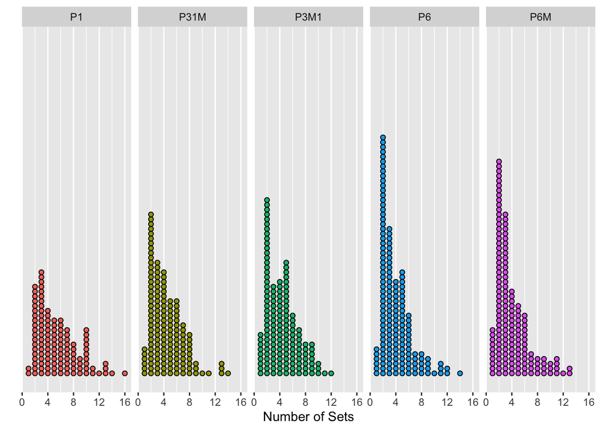

```r
df_nsets %>%
  ggplot(.) +
  aes(Nsets, fill = Group) +
  geom_dotplot(dotsize=1.5) +
  facet_grid(. ~ Group) +
  labs(x="Number of Sets", y="") +
  theme(axis.text.y = element_blank()) +
  scale_y_continuous(breaks=NULL) +
  guides( fill=FALSE )
```

We do not have participant-level demographic data on Databrary, so we will have to find those.

## Exemplar-pair data

The `make.symm.df()` function loads the sorting data from `analysis/data/xlsx`. I modified it slightly to return the exemplar codes as column names. Also added are two helper functions that save CSVs by wallpaper group: `save_sorting_csv()` and `save_all_sorting_csv()`. This should make it easier to match the exemplar codes with their actual images when that time comes.

The function `make.jaccard.df()` takes a list of data.frames generated by `make.symm.df()` and then computes the Jaccard indices using `jaccard.data()`. Let’s test it with a single data file

```r
p1 <- readr::read_csv("analysis/data/P1-sorting.csv")
jaccard.data(p1)
```

```
##     Exemplar.Row Exemplar.Col            Jaccard Group
## 1         101001       101002  0.269230769230769    P1
## 2         101001       101003  0.178571428571429    P1
## 3         101001       101004   0.11864406779661    P1
## 4         101001       101005  0.222222222222222    P1
## 5         101001       101006                0.2    P1
## 6         101001       101007  0.157894736842105    P1
## 7         101001       101008  0.178571428571429    P1
## 8         101001       101009  0.245283018867925    P1
## 9         101001       101010  0.222222222222222    P1
## 10        101001       101011  0.203703703703704    P1
## 11        101001       101012  0.157894736842105    P1
## 12        101001       101013                0.2    P1
## 13        101001       101014  0.157894736842105    P1
## 14        101001       101015               0.32    P1
```

[output cut: 176 more lines]

That works, but I want the exemplar codes rather than indices. I edited `jaccard.data()`, to replaces the image indices with their codes since these are available in the column names.

Now, we can make a data frame with all of the Jaccard values for all of the wallpaper groups.

```r
get_sorting_df <- function(wp) {
  fn <- list.files("analysis/data", paste0('^', wp, '\\-'), full.names = TRUE)
  readr::read_csv(fn)
}

all_sorting_list <- purrr::map(c("P1", "P31M", "P3M1", "P6", "P6M"), get_sorting_df)
j_all <- purrr::map_df(all_sorting_list, jaccard.data)
```

Let’s save this as an intermediate result.

```r
readr::write_csv(j_all, "analysis/data/jaccard-no-duplicates.csv")
```

### Image metrics

The function `compute.image.metric()` relies on helper function `load.wp()` to load the images from Databrary. It looks like the CSV that supports this was generated by hand. I’m going to pull the names from Databrary directly to avoid any mishaps. To do so, I’ll write a function that given an exemplar code, the Databrary slot and asset values are returned.

```r
db_77 <- databraryapi::list_containers_records(vol_id = 77)
db_77$containers
```

```
##     id  top                name
## 1 6508 TRUE                <NA>
## 2 6509 TRUE         displays-p1
## 3 6510 TRUE       displays-p3m1
## 4 6511 TRUE       displays-p31m
## 5 6512 TRUE        displays-p6m
## 6 6513 TRUE         displays-p6
## 7 9846 TRUE Top-level materials
```

```r
displays_df <- db_77$containers %>%
  dplyr::filter(., str_detect(name, 'displays'))

p1_s <- databraryapi::list_assets_in_session(displays_df$id[1])

make_databrary_image_df <- function(i, df = displays_df) {
  require(tidyverse)

  wp_group <- stringr::str_remove(df$name[i], 'displays-')
  out_df <- databraryapi::list_assets_in_session(df$id[i])
  out_df$group <- wp_group

  out_df <- out_df %>%
    dplyr::select(., group, session_id, asset_id, name) %>%
    dplyr::rename(., asset = asset_id, slot = session_id) %>%
    dplyr::arrange(., group, slot, asset) %>%
    dplyr::mutate(
      .,
      url = paste(
        'https://nyu.databrary.org/slot',
        slot,
        '-/asset',
        asset,
        'download?inline=true',
        sep = '/'
      )
    ) %>%
    dplyr::mutate(., img_index = 1:length(asset))
  out_df
}

displays_databrary_df <-
  purrr::map_df(1:5, make_databrary_image_df)
```

Rick loves functional programming.

Now, we have a data frame we can merge/join with any image metric data we want. Let’s save it and replace `wallpapers-on-databrary.csv`.

```r
readr::write_csv(displays_databrary_df, 'analysis/data/wallpapers-on-databrary.csv')
```

Now we can look at `compute.image.metric()` again.

I made some changes to the function to allow it to save the exemplar codes.

**TODO:(ROG)** grab the image metric from the function call and write it to the data frame.

The default image metric is `ssid` so let’s add that in a column, and save it appropriately.

```r
ssid <- purrr::map_df(c("P1", "P31M", "P3M1", "P6", "P6M"), compute.image.metric)
ssid$measure_type = 'ssid'
```

```r
readr::write_csv(ssid, 'analysis/data/ssid.csv')
```

Now, we should be able to merge/join these.

```r
wp_merge <- dplyr::full_join(j_all, ssid, by = c('Exemplar.Row', 'Exemplar.Col', 'Group'))
```

The previous chunk fails, so we set `eval=FALSE`.

We’ll reimport the CSVs because of the type conflicts invoked by using data.frames and tibbles interchangeably.

```r
ssid <- readr::read_csv("analysis/data/ssid.csv")
jaccard <- read_csv("analysis/data/jaccard-no-duplicates.csv")
wp_merge <- dplyr::left_join(jaccard, ssid, by = c('Exemplar.Row', 'Exemplar.Col', 'Group'))
```

Let’s do one last bit before we break. Add in the image pixel-wise dot product.

```r
dot_prod <- purrr::map_df(c("P1", "P31M", "P3M1", "P6", "P6M"), compute.image.metric, FUN = image.dot.prod)
```

[output not shown]

[output cut: 514 more lines]

[output not shown]

[output not shown]

[output cut: 514 more lines]

[output not shown]

[output not shown]

[output cut: 514 more lines]

[output not shown]

[output not shown]

[output cut: 514 more lines]

[output not shown]

[output not shown]

[output cut: 514 more lines]

[output not shown]

```r
dot_prod$measure_type = 'dot_prod'
```

```r
readr::write_csv(dot_prod, 'analysis/data/dot_prod.csv')
```

That works, but you forget that your `ssid` and `dot_prod` data sets were only for the one ‘P1’ group.

I fixed that error.

Now, let’s merge the dot product data.

```r
wp_merge_clean <- wp_merge %>%
  dplyr::select(., Exemplar.Row,
  Exemplar.Col, Jaccard, Measure_Val, Group) %>%
  dplyr::rename(., Exemplar_1 = Exemplar.Row,
                Exemplar_2 = Exemplar.Col,
                SSID = Measure_Val)

dot_prod_clean <- dot_prod %>%
  dplyr::select(., Exemplar.Row,
  Exemplar.Col, Measure_Val, Group) %>%
  dplyr::rename(., Exemplar_1 = Exemplar.Row,
                Exemplar_2 = Exemplar.Col,
                Dot_Prod = Measure_Val)

wp_merge_clean <- dplyr::left_join(wp_merge_clean, dot_prod_clean, by = c('Exemplar_1', 'Exemplar_2', 'Group')) %>%
  dplyr::select(., Group, Exemplar_1, Exemplar_2, Jaccard, SSID, Dot_Prod)
```

Now, let’s add back in the Databrary URLs.

```r
databrary_clean <- displays_databrary_df %>%
  dplyr::rename(., Group = group) %>%
  dplyr::mutate(., Group = toupper(Group))
```

```r
lookup_databrary_for_exemplar <- function(ex) {
  databrary_clean$url[databrary_clean$name == ex]
}

wp_merge_clean_databrary <- wp_merge_clean %>%
  dplyr::mutate(
    .,
    Exemplar_1_URL = unlist(purrr::map(Exemplar_1, lookup_databrary_for_exemplar)),
    Exemplar_2_URL = unlist(purrr::map(Exemplar_2, lookup_databrary_for_exemplar))
    )

readr::write_csv(wp_merge_clean_databrary, "analysis/data/wallpapers-sorting-image.csv")
```